### Final Project Group 2

# Introduction

Regork's CEO is faced with declining customer engagement and revenue performance. Addressing these issues is critical for improving profitability and maintaining market competitiveness.

**Problem Statement:** How can the grocery chain effectively identify low-performing products that generate minimal sales among repeat customers and strategically invest in those products to increase overall revenue and profitability?

**Methodology:** We analyzed customer transaction data using exploratory data analysis (EDA) and machine learning techniques to identify patterns, segment customers, and optimize marketing strategies.

**Solution Overview**: The Complete Journey dataset offers detailed household-level transaction data collected over 2017 from 2,469 frequent grocery store shoppers. By leveraging data insights, we propose which product types have untapped potential, analyzing purchasing patterns of repeat customers, and implementing targeted promotional strategies or product enhancements to drive increased customer engagement and higher sales for these underperforming categories.

## Import Packages/Libraries Required

```python
#Data Cleaning and Preprocessing
import pandas as pd

#Used for Plotting
import matplotlib.pyplot as plt
import seaborn as sns
import matplotlib.patches as mpatches

#Loading the Dataset
from completejourney_py import get_data
```

# Load the datasets

```python
cj_data = get_data()
demographics = cj_data['demographics']
transactions = cj_data['transactions']
products = cj_data['products']
coupons=cj_data['coupons']
campaigns=cj_data['campaigns']
campaign_descriptions=cj_data['campaign_descriptions']
coupon_redemptions=cj_data['coupon_redemptions']
promotions=cj_data['promotions']
```

The Complete Journey Data does not sufficiently provide Demographics for All Customers. In Part 1 we will calculate Repeating Customers based on the sample of Household Id's where Demographic data is avaliable. In Part 2 we will use entire Transactions data to **accurately** calculate further analysis

# Part I - EDA

### **The goal of this part is to identify the attributes of our customers.**

We want to identify which segments of Income, Age and Household Composition do our Repeating Customers & One-Time Customers come from

```python
transactions['transaction_timestamp'] = pd.to_datetime(transactions['transaction_timestamp'])
repeating_customers = (
    transactions.groupby('household_id')['transaction_timestamp']
    .nunique()
    .reset_index(name='purchase_days')
)
repeating_customers
```

|  | household_id | purchase_days |
| --- | --- | --- |
| 0 | 1 | 51 |
| 1 | 2 | 20 |
| 2 | 3 | 20 |
| 3 | 4 | 18 |
| 4 | 5 | 20 |
| ... | ... | ... |
| 2464 | 2496 | 41 |
| 2465 | 2497 | 124 |
| 2466 | 2498 | 134 |
| 2467 | 2499 | 46 |
| 2468 | 2500 | 73 |

2469 rows × 2 columns

```python
repeating_customers['purchase_days'].describe()
```

```
count    2469.000000
mean       63.087890
std        69.798999
min         1.000000
25%        20.000000
50%        43.000000
75%        83.000000
max       775.000000
Name: purchase_days, dtype: float64
```

```python
repeating_customers['purchase_days'].describe()

repeating_customers['Repeating_Customer'] = repeating_customers['purchase_days'].apply(lambda x: 'Y' if x > 20 else 'N')
repeating_customers = repeating_customers.drop(columns=['purchase_days'])
repeating_customers
```

|  | household_id | Repeating_Customer |
| --- | --- | --- |
| 0 | 1 | Y |
| 1 | 2 | N |
| 2 | 3 | N |
| 3 | 4 | N |
| 4 | 5 | N |
| ... | ... | ... |
| 2464 | 2496 | Y |
| 2465 | 2497 | Y |
| 2466 | 2498 | Y |
| 2467 | 2499 | Y |
| 2468 | 2500 | Y |

2469 rows × 2 columns

## Check to see the highest spending households

```python
rc_df = (
    transactions.merge(repeating_customers, on='household_id', how='right')
    .groupby(['household_id', 'Repeating_Customer'])['sales_value']
    .sum()
    .reset_index()
    .sort_values('sales_value', ascending=False)
)
rc_df
```

|  | household_id | Repeating_Customer | sales_value |
| --- | --- | --- | --- |
| 1015 | 1023 | Y | 24879.75 |
| 1593 | 1609 | Y | 16581.36 |
| 1440 | 1453 | Y | 13376.23 |
| 2294 | 2322 | Y | 13187.54 |
| 1417 | 1430 | Y | 12849.31 |
| ... | ... | ... | ... |
| 843 | 851 | N | 8.37 |
| 228 | 231 | N | 7.50 |
| 1844 | 1863 | N | 5.99 |
| 237 | 240 | N | 4.49 |
| 959 | 967 | N | 2.00 |

2469 rows × 3 columns

## Check how many repeating and one-time customers we have demographics information about

```python
combined_df = (
    rc_df.merge(demographics[['household_id','income','age','household_comp']],on='household_id',how='inner')
    .sort_values('sales_value',ascending=False)
)
combined_df
```

|  | household_id | Repeating_Customer | sales_value | income | age | household_comp |
| --- | --- | --- | --- | --- | --- | --- |
| 0 | 1609 | Y | 16581.36 | 125-149K | 45-54 | 2 Adults Kids |
| 1 | 1453 | Y | 13376.23 | 125-149K | 45-54 | 2 Adults Kids |
| 2 | 2322 | Y | 13187.54 | 175-199K | 45-54 | 1 Adult No Kids |
| 3 | 1430 | Y | 12849.31 | 35-49K | 35-44 | 2 Adults Kids |
| 4 | 400 | Y | 11801.64 | 150-174K | 35-44 | 2 Adults Kids |
| ... | ... | ... | ... | ... | ... | ... |
| 796 | 992 | Y | 431.94 | 35-49K | 45-54 | 2 Adults Kids |
| 797 | 1429 | Y | 428.10 | 35-49K | 45-54 | 1 Adult No Kids |
| 798 | 1695 | Y | 416.97 | 25-34K | 35-44 | 1 Adult No Kids |
| 799 | 460 | Y | 389.68 | 25-34K | 65+ | 1 Adult No Kids |
| 800 | 1135 | Y | 338.11 | 50-74K | 45-54 | 1 Adult Kids |

801 rows × 6 columns

```python
combined_df['Repeating_Customer'].value_counts()
```

```
Repeating_Customer
Y    795
N      6
Name: count, dtype: int64
```

*Out of the total 2469 Households we have transactions for, we will sample the 801 which demographic data is present to understand their attributes*

## Plot visualizations for Customers with Demographic Data

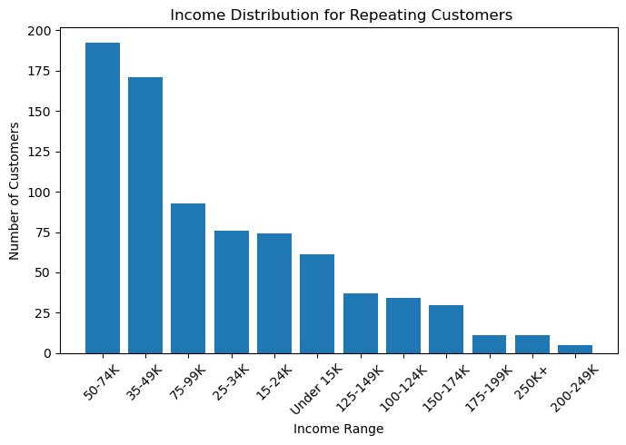

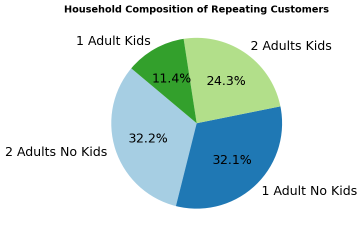

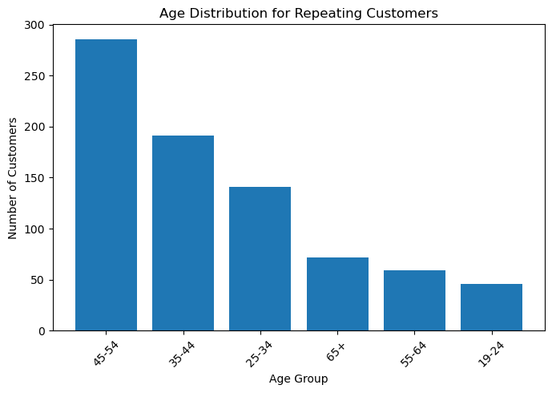

```python
#Segregate repeating customers and One-time Customers
repeating_cust = (
    combined_df[combined_df['Repeating_Customer']=='Y']
    .nlargest(795,'sales_value')
)
one_time_cust = (
    combined_df[combined_df['Repeating_Customer']=='N']
    .nsmallest(6,'sales_value')
)

#Plot Income (Bar Chart) for Repeating Customers:
income_counts = repeating_cust['income'].value_counts()


plt.figure(figsize=(7, 5))
plt.bar(income_counts.index, income_counts.values)
plt.title(' Income Distribution for Repeating Customers')
plt.xlabel('Income Range')
plt.ylabel('Number of Customers')
plt.xticks(rotation=45)
plt.tight_layout()
plt.show()

#Plot Household Compositions for Repeating Customers (Pie Chart)
household_comp_counts = repeating_cust['household_comp'].value_counts()

plt.figure(figsize=(7,7))
plt.pie(household_comp_counts,labels=household_comp_counts.index,autopct='%1.1f%%',startangle=140,textprops={'fontsize': 18},colors=plt.cm.Paired.colors)
plt.title('Household Composition of Repeating Customers', fontsize=14, fontweight='bold')
plt.tight_layout()
plt.show()

# Plot Age (Chart) for Repeating Customers
age_counts = repeating_cust['age'].value_counts()
plt.figure(figsize=(7, 5))
plt.bar(age_counts.index, age_counts.values)
plt.title('Age Distribution for Repeating Customers')
plt.xlabel('Age Group')
plt.ylabel('Number of Customers')
plt.xticks(rotation=45)
plt.tight_layout()
plt.show()
```

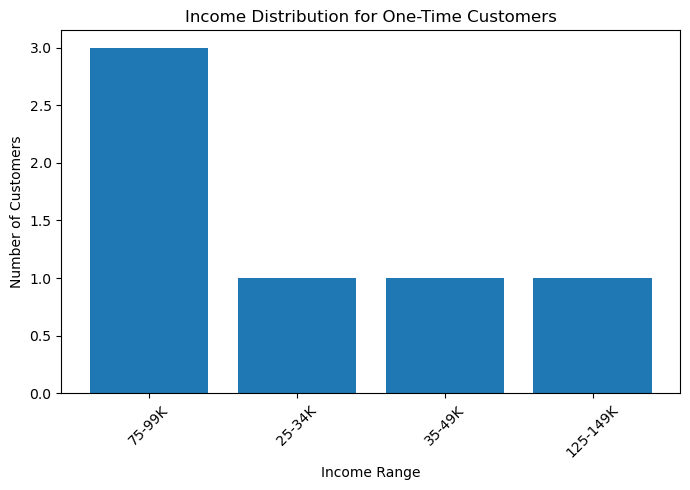

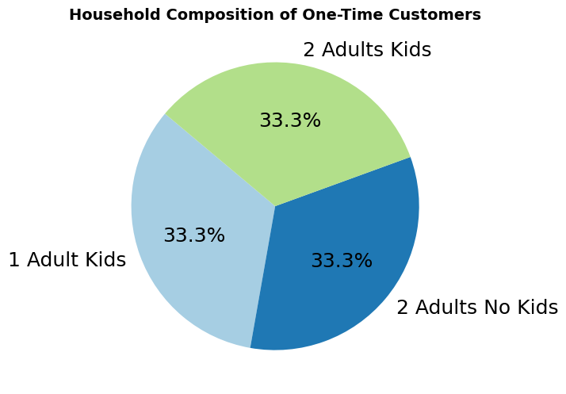

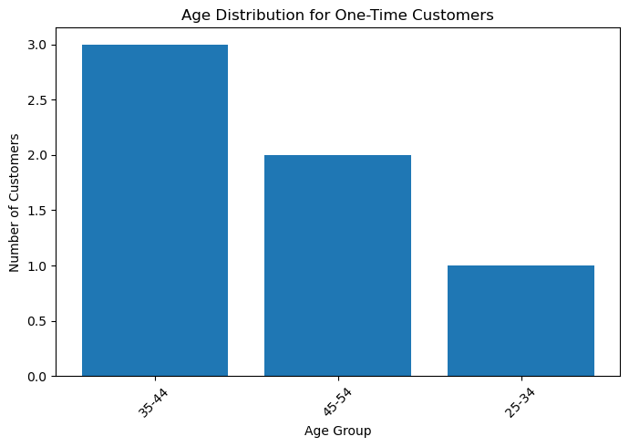

```python
#Plot Income (Bar Chart) for One-Time Customers:

income_counts = one_time_cust['income'].value_counts()
plt.figure(figsize=(7, 5))
plt.bar(income_counts.index, income_counts.values)
plt.title('Income Distribution for One-Time Customers')
plt.xlabel('Income Range')
plt.ylabel('Number of Customers')
plt.xticks(rotation=45)
plt.tight_layout()
plt.show()

#Plot Household Compositions for One-Time Customers (Pie Chart)
household_comp_counts = one_time_cust['household_comp'].value_counts()
plt.figure(figsize=(7, 7))
plt.pie(household_comp_counts, labels=household_comp_counts.index, autopct='%1.1f%%', startangle=140,textprops={'fontsize': 18},colors=plt.cm.Paired.colors)
plt.title('Household Composition of One-Time Customers',fontsize=14,fontweight='bold')
plt.tight_layout()
plt.show()

# Plot Age ( Chart) for One-Time Customers
age_counts = one_time_cust['age'].value_counts()
plt.figure(figsize=(7, 5))
plt.bar(age_counts.index, age_counts.values)
plt.title('Age Distribution for One-Time Customers')
plt.xlabel('Age Group')
plt.ylabel('Number of Customers')
plt.xticks(rotation=45)
plt.tight_layout()
plt.show()
```

### From our charts, it is evident that:

#### * Middle-income households are a key customer base, and promotions targeting this demographic may yield higher retention and spending.

#### * Households without kids dominate the repeating customers' segment. Marketing campaigns tailored to family needs can drive engagement and loyalty amongst our weaker customers

#### * Targeting the 35-54 age group with relevant products and services could boost revenue further. Outreach to younger demographics can capture future repeat customers.

# Part II

Now we will focus on Repeating Customers from Our Entire Transactions Dataset

## Check how many repeating Household Id's we have based on Transactions data

```python
rc_df['Repeating_Customer'].value_counts()
```

```
Repeating_Customer
Y    1832
N     637
Name: count, dtype: int64
```

We have 1832 Repeating Customers

## Merge our transactions dataset with our HouseHold and Product Information

```python
# Merging rc_df with transactions
rc_df_2 = (
    rc_df
    .merge(transactions, on='household_id', how='inner')
)

# Merging rc_df_2 with selected columns from products
combined_rc_df_2 = (
    rc_df_2
    .merge(
        products[['product_id', 'department', 'product_category', 'product_type']],
        on='product_id',
        how='inner'
    )
)
```

## Create seperate dataframes for Repeating Customers

```python
top_50_repeating_products = (
    combined_rc_df_2[combined_rc_df_2['Repeating_Customer']=='Y']
    .nlargest(50,'sales_value_x')
)
top_50_repeating_products.head()
```

|  | household_id | Repeating_Customer | sales_value_x | store_id | basket_id | product_id | quantity | sales_value_y | retail_disc | coupon_disc | coupon_match_disc | week | transaction_timestamp | department | product_category | product_type |
| --- | --- | --- | --- | --- | --- | --- | --- | --- | --- | --- | --- | --- | --- | --- | --- | --- |
| 0 | 1023 | Y | 24879.75 | 429 | 31198611703 | 1076273 | 1 | 21.99 | 0.00 | 0.00 | 0.00 | 1 | 2017-01-01 20:59:01 | DRUG GM | COLD AND FLU | VAPORIZERS |
| 1 | 1023 | Y | 24879.75 | 429 | 31225525405 | 6534166 | 14730 | 32.54 | 2.21 | 0.00 | 0.00 | 2 | 2017-01-02 15:31:03 | MISCELLANEOUS | COUPON/MISC ITEMS | GASOLINE-REG UNLEADED |
| 2 | 1023 | Y | 24879.75 | 429 | 31254571442 | 919423 | 3 | 13.50 | 4.47 | 0.00 | 0.00 | 2 | 2017-01-04 19:37:25 | GROCERY | WATER - CARBONATED/FLVRD DRINK | SPRING WATER |
| 3 | 1023 | Y | 24879.75 | 429 | 31254571442 | 927011 | 1 | 1.82 | 0.00 | 0.75 | 0.25 | 2 | 2017-01-04 19:37:25 | GROCERY | FRZN BREAKFAST FOODS | FRZN BREAKFAST PASTRY |
| 4 | 1023 | Y | 24879.75 | 429 | 31254571442 | 936830 | 1 | 3.79 | 0.00 | 0.00 | 0.00 | 2 | 2017-01-04 19:37:25 | GROCERY | FLUID MILK PRODUCTS | FLUID MILK WHITE ONLY |

## Product Department by Revenue for Repeated Customers

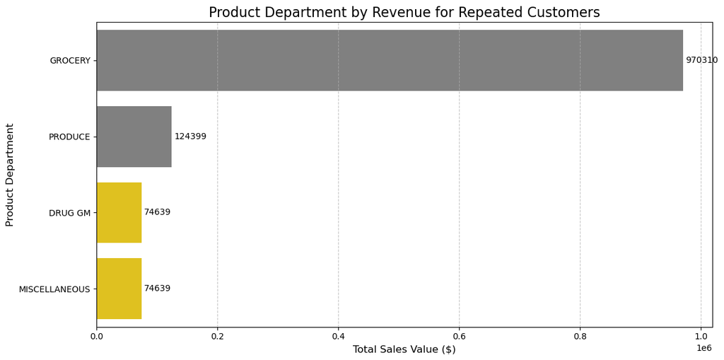

```python
# Group by department and calculate the sum of sales_value_x
category_sales = (
    top_50_repeating_products.groupby("department", as_index=False)["sales_value_x"]
    .sum()
    .sort_values("sales_value_x", ascending=False)
)

# Highlight the lowest sales value
category_sales["highlight"] = (
    category_sales["sales_value_x"] == category_sales["sales_value_x"].min()
)

# Define a palette for the bar chart
palette = ["gold" if highlight else "gray" for highlight in category_sales["highlight"]]

# Plot the bar chart
plt.figure(figsize=(12, 6))
ax = sns.barplot(
    data=category_sales,
    x="sales_value_x",
    y="department",
    hue='department',
    palette=palette,
)

# Add data labels
for container in ax.containers:
    ax.bar_label(container, fmt="%.0f", label_type="edge", fontsize=10, padding=3)

# Add gridlines
plt.grid(axis="x", linestyle="--", alpha=0.7)

# Set titles and labels
plt.title("Product Department by Revenue for Repeated Customers", fontsize=16)
plt.xlabel("Total Sales Value ($)", fontsize=12)
plt.ylabel("Product Department", fontsize=12)

plt.tight_layout()
plt.show()
```

### The above graphs highlights that:

#### * Drug GM and miscellaneous departments contribute significantly less revenue compared to Grocery and Produce. This could imply underutilization of their potential in attracting repeated customers or that their products are not as appealing to this customer segment.

#### * The drug line cater to niche demands, efforts could be made to attract a broader customer base or better target the niche audience through personalized marketing campaigns.

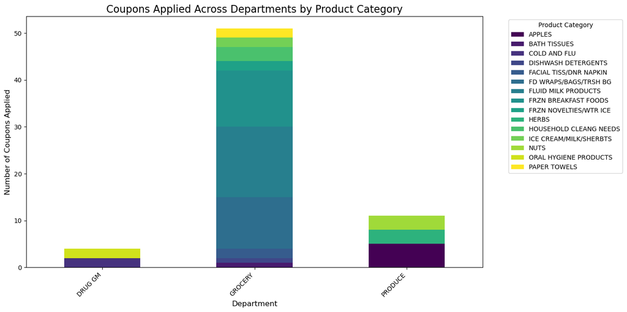

```python
coupon_dep = top_50_repeating_products.merge(coupons, how='inner', on='product_id')

coupon_dep = coupon_dep.dropna(subset=['department', 'product_category', 'coupon_upc'])

coupon_dep1 = (
    coupon_dep.groupby(['department', 'product_category'])['coupon_upc']
    .count()
    .reset_index()
    .rename(columns={'coupon_upc': 'coupon_count'})
)


group_data = coupon_dep1.pivot(
    index='department', columns='product_category', values='coupon_count'
).fillna(0)


group_data.plot(kind='bar', stacked=True, figsize=(14, 7), colormap='viridis')


plt.title('Coupons Applied Across Departments by Product Category', fontsize=16)
plt.xlabel('Department', fontsize=12)
plt.ylabel('Number of Coupons Applied', fontsize=12)
plt.xticks(rotation=45, ha='right')
plt.legend(title='Product Category', bbox_to_anchor=(1.05, 1), loc='upper left')


plt.tight_layout()
plt.show()
```

#### The bar chart clearly demonstrates that the grocery department has the highest number of coupons applied compared to other departments.

#### This category's significant volume of coupon applications highlights its importance in driving customer purchases and encouraging repeat shopping behavior.

#### This trend may reflect consumer preferences for discounts on everyday necessities, making groceries a key target for promotional strategies.

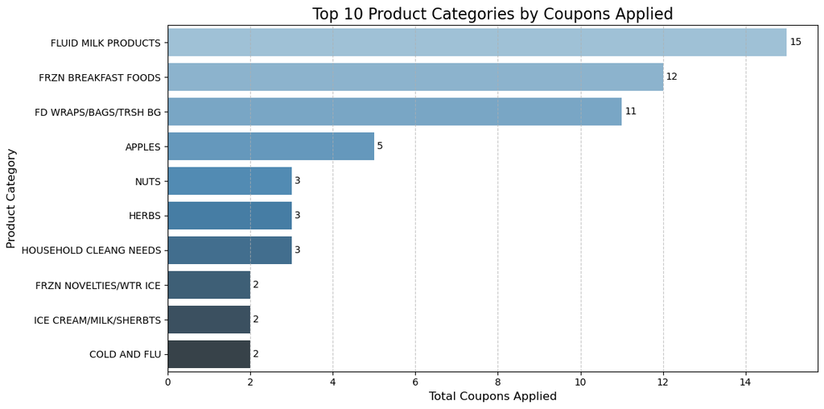

```python
coupons_cat = top_50_repeating_products.merge(coupons, how='inner', on='product_id')

coupons_cat = coupons_cat.dropna(subset=['product_category', 'coupon_upc'])


coupons_cat1 = (
    coupons_cat.groupby('product_category')['coupon_upc']
    .count()
    .reset_index()
    .rename(columns={'coupon_upc': 'coupon_count'})
)


coupons_cat1 = coupons_cat1.sort_values('coupon_count', ascending=False).head(10)


plt.figure(figsize=(12, 6))


cou_cat = sns.barplot(data=coupons_cat1, x='coupon_count', y='product_category',hue='product_category', palette='Blues_d')


for container in cou_cat.containers:
    cou_cat.bar_label(container, fmt='%.0f', label_type='edge', fontsize=10, padding=3)


plt.grid(axis='x', linestyle='--', alpha=0.7)

plt.title('Top 10 Product Categories by Coupons Applied', fontsize=16)
plt.xlabel('Total Coupons Applied', fontsize=12)
plt.ylabel('Product Category', fontsize=12)


plt.tight_layout()
plt.show()
```

#### According to the graph, milk products have the highest amount of coupon usage, followed by frozen breakfast foods.

#### Additionally, the top three product categories account for a significant proportion of overall coupon usage, indicating a strong focus on staple or frequently purchased items.

## Coupons Applied Across Departments, Display Locations, and Product Categories

[figure not shown]

```python
# Convert product_id to a consistent type (string) in all DataFrames
top_50_repeating_products['product_id'] = top_50_repeating_products['product_id'].astype(str)
coupons['product_id'] = coupons['product_id'].astype(str)
promotions['product_id'] = promotions['product_id'].astype(str)

# Step 1: Merge top_50_repeating_products with coupons
coupon_dep = top_50_repeating_products.merge(coupons, how='inner', on='product_id')

# Step 2: Add display_location by merging with promotions
coupon_dep = coupon_dep.merge(promotions[['product_id', 'display_location']], how='left', on='product_id')

# Step 3: Drop rows with missing values for relevant columns
coupon_dep = coupon_dep.dropna(subset=['department', 'product_category', 'coupon_upc', 'display_location'])

# Step 4: Exclude rows where display_location equals 0
coupon_dep = coupon_dep[coupon_dep['display_location'] != '0']

# Step 5: Group by department, product category, and display location
coupon_dep1 = (
    coupon_dep.groupby(['department', 'product_category', 'display_location'])['coupon_upc']
    .count()
    .reset_index()
    .rename(columns={'coupon_upc': 'coupon_count'})
)

# Step 6: Pivot data for plotting
group_data = coupon_dep1.pivot_table(
    index=['department', 'display_location'],
    columns='product_category',
    values='coupon_count',
    aggfunc='sum'
).fillna(0)

# Step 7: Create a Stacked Bar Chart
ax = group_data.plot(kind='bar', stacked=True, figsize=(16, 9), colormap='viridis')

# Add titles and labels
plt.title('Coupons Applied Across Departments, Display Locations', fontsize=16)
plt.xlabel('Department and Display Location', fontsize=12)
plt.ylabel('Number of Coupons Applied', fontsize=12)
plt.xticks(rotation=45, ha='right')

# Define a legend table for display locations
display_location_legend = {
    '1': 'store front',
    '2': 'store rear',
    '3': 'front end cap',
    '4': 'mid-aisle end cap',
    '5': 'rear end cap',
    '6': 'side aisle end cap',
    '7': 'in-aisle',
    '9': 'secondary location display',
    'A': 'in-shelf'
}

# Create legend patches
legend_patches = [
    mpatches.Patch(color='white', label=f"{key} - {value}")
    for key, value in display_location_legend.items()
]

# Add the legend table
plt.legend(
    title='Display Location (Legend)',
    handles=legend_patches,
    bbox_to_anchor=(1.05, 1),
    loc='upper left',
    frameon=True
)

# Adjust layout
plt.tight_layout()
plt.show()
```

#### From this graph, we can tell which positions had the greatest Coupon Redemptions for the following departments:

#### **Grocery:** Front-End Cap

#### **Drugs:** Side Aisle End Cap

# Summary

**Recommendations for CEO**

- Analysis of repeating customers show that middle-income households are a key customer base, and promotions targeting this demographic may yield higher retention and spending.¶
- Targeting the 35-54 age group with relevant products and services could boost revenue further. Outreach to younger demographics can capture future repeat customers.
- The drug line cater to niche demands, efforts could be made to attract a broader customer base or better target the niche audience through personalized marketing campaigns.
- Offer more coupons on departments such as Drugs and Produce to maximize revenue from redemptions
- Strategic Placement of Products: grocery products in the Front-End Cap of stores, Drugs in the Side Aisle and Produce towards the store front

**Limitations**

- Collect more data for remaining households to better understand the demographics of the customers of the grocery chain
- Collect newer data. Since this data is from 2017, it is hard to accurately predict trends in 2024. Including more recent transaction history so it represent the customer behavior of recent time.
- Inclusion of Product Brand Names can help classify product types better. Some brands might offer coupons different than others of the same product type but it cannot be represented accurately without brand data